# Segmenting and Clustering Neighborhoods in Fredericton, NB

## Applied Data Science Capstone Week 5 Peer-Graded Project Report

By BADEMIYA SYED

## Introduction to the opportunity

Fredericton is the Capital City of the only Canadian fully-bilingual Province of New Brunswick and is beautifully located on the banks of the Saint John River. While one of the least populated provincial capital cities with a population base of less than 60 thousand residents, it offers a wide spectrum of venues and is a governement, university and cultural hub.

As the city grows and develops, it becomes increasingly important to examine and understand it quantitiatively. The City of Fredericton provides open data for everyone and encourages entrepreneurial use to develop services for the benefit of its ciitzens.

Developers, investors, policy makers and/or city planners have an interest in answering the following questions as the need for additional services and citizen protection:

1. What neighbourhoods have the highest crime?
2. Is population density correlated to crime level?
3. Using Foursquare data, what venues are most common in different locations within the city?
4. Does the Knowledge Park really need a coffee shop?

Does the Open Data project have specific enough or thick enough data to empower decisions to be made or is it too aggregate to provide value in its current detail? Let's find out.

```python
from IPython.display import Image
from IPython.core.display import HTML
Image(url= "http://www.tourismfredericton.ca/sites/default/files/field/image/fredericton.jpg")
```

[figure not shown]

## Data

To understand and explore we will need the following City of Fredericton Open Data:

1. Open Data Site: http://data-fredericton.opendata.arcgis.com/
2. Fredericton Neighbourhoods: http://data-fredericton.opendata.arcgis.com/datasets/neighbourhoods--quartiers
3. Fredericton Crime by Neighbourhood: http://data-fredericton.opendata.arcgis.com/datasets/crime-by-neighbourhood-2017--crime-par-quartier-2017
4. Fredericton Census Tract Demographics: http://data-fredericton.opendata.arcgis.com/datasets/census-tract-demographics--donn%C3%A9es-d%C3%A9mographiques-du-secteur-de-recensement
5. Fredericton locations of interest: https://github.com/JasonLUrquhart/Applied-Data-Science-Capstone/blob/master/Fredericton%20Locations.xlsx
6. Foursquare Developers Access to venue data: https://foursquare.com/

Using this data will allow exploration and examination to answer the questions. The neighbourhood data will enable us to properly group crime by neighbourhood. The Census data will enable us to then compare the population density to examine if areas of highest crime are also most densely populated. Fredericton locations of interest will then allow us to cluster and quantitatively understand the venues most common to that location.

# Methodology

All steps are referenced beleow in the Appendix: Analysis section.

The methodology will include:

1. Loading each data set
2. Examine the crime frequency by neighbourhood
3. Study the crime types and then pivot analysis of crime type frequency by neighbourhood
4. Understand correlation between crimes and population density
5. Perform k-means statisical analysis on venues by locations of interest based on findings from crimes and neighbourhood
6. Determine which venues are most common statistically in the region of greatest crime count then in all other locations of interest.
7. Determine if an area, such as the Knowledge Park needs a coffee shop.

### Loading the data

After loading the applicable libraries, the referenced geojson neighbourhood data was loaded from the City of Fredericton Open Data site. This dataset uses block polygon shape coordinates which are better for visualization and comparison. The City also uses Ward data but the Neighbourhood location data is more accurate and includes more details. The same type of dataset was then loaded for the population density from the Stats Canada Census tracts.

The third dataset, an excel file, "Crime by Neighbourhood 2017" downloaded from the City of Fredericton Open Data site is found under the Public Safety domain. This dataset was then uploaded for the analysis. It's interesting to note the details of this dataset are aggregated by neighbourhood. It is not an exhaustive set by not including all crimes (violent offenses) nor specific location data of the crime but is referenced by neighbourhood.

This means we can gain an understanding of the crime volume by type by area but not specific enough to understand the distribution properties. Valuable questions such as, "are these crimes occuring more often in a specific area and at a certain time by a specific demographic of people?" cannot be answered nor explored due to what is reasonably assumed to be personal and private information with associated legal risks.

There is value to the city to explore the detailed crime data using data science to predict frequency, location, timing and conditions to best allocated resources for the benefit of its citizens and it's police force. However, human behaviour is complex requiring thick profile data by individual and the conditions surrounding the event(s). To be sufficient for reliable future prediction it would need to demonstrate validity, currency, reliability and sufficiency.

### Exploring the data

Exploring the count of crimes by neighbourhood gives us the first glimpse into the distribution.

One note is the possibility neighbourhoods names could change at different times. The crime dataset did not mention which specific neighbourhood naming dataset it was using but we assumed the neighbourhood data provided aligned with the neighbourhoods used in the crime data. It may be beneficial for the City to note and timestamp neighbourhood naming in the future or simply reference with neighbourhood naming file it used for the crime dataset.

An example of data errors: There was an error found in the naming of the neighbourhood "Platt". The neighbourhood data stated "Plat" while the crime data stated "Platt". Given the crime dataset was most simple to manipulate it was modified to "Plat". The true name of the neighbourhood is "Platt".

#### First Visualization of Crime

Once the data was prepared, a choropleth map was created to view the crime count by neighbourhood. As expected the region of greatest crime count was found in the downtown and Platt neighbourhoods.

Examining the crime types enables us to learn the most frequent occuring crimes which we then plot as a bar chart to see most frequenty type.

Theft from motor vehicles is most prevalent in the same area as the most frequent crimes. It's interesting to note this area is mostly residential and most do not have garages. It would be interesting to further examine if surveillance is a deterant for motor vehicle crimes in the downtown core compared to low surveillance in the Platt neighbourhood.

#### Examining 2nd most common crime given it is specific: theft from vehicles

After exploring the pivot table showing Crime_Type by Neighbourhood, we drill into a specific type of crime, theft from vehicles and plot the choropleth map to see which area has the greatest frequency.

Again, the Platt neighbourhood appears as the most frequent.

Is this due to population density?

#### Introducing the Census data to explore the correlation between crime frequency and population density.

Visualising the population density enables us to determine that the Platt neighbourhood has lower correlation to crime frequency than I would have expected.

It would be interesting to further study the Census data and if this captures the population that is renting or more temporary/transient poplution, given the City is a University hub.

### Look at specific locations to understand the connection to venues using Foursquare data

Loading the "Fredericton Locations" data enables us to perform a statistical analysis on the most common venues by location.

We might wonder if the prevalence of bars and clubs in the downtown region has something to do with the higher crime rate in the near Platt region.

Plotting the latitude and longitude coordinates of the locations of interest onto the crime choropleth map enables us to now study the most common venues by using the Foursquare data.

#### Analysing each Location

Grouping rows by location and the mean of the frequency of occurance of each category we venue categories we study the top five most common venues.

Putting this data into a pandas dataframe we can then determine the most common venues by location and plot onto a map.

## Results

The analysis enabled us to discover and describe visually and quantitatively:

While, it is not valid, consistent, reliable or sufficient to assume a higher concentration of the combination of coffee shops, bars and clubs predicts the amount of crime occurance in the City of Fredericton, this may be a part of the model needed to be able to in the future.

1. We were able to determine the top 10 most common venues by location of interest.
2. Statisically, we determined there are no coffee shops within the Knowledge Park clusters.

## Discussion and Recommendations

The City of Fredericton Open Data enables us to gain an understanding of the crime volume by type by area but not specific enough to understand the distribution properties. Valuable questions such as, "are these crimes occuring more often in a specific area and at a certain time by a specific demographic of people?" cannot be answered nor explored due to what is reasonably assumed to be personal and private information with associated legal risks.

There is value to the city to explore the detailed crime data using data science to predict frequency, location, timing and conditions to best allocated resources for the benefit of its citizens and it's police force. However, human behaviour is complex requiring thick profile data by individual and the conditions surrounding the event(s). To be sufficient for reliable future prediction it would need to demonstrate validity, currency, reliability and sufficiency.

A note of caution is the possibility neighbourhoods names could change. The crime dataset did not mention which specific neighbourhood naming dataset it was using but we assumed the neighbourhood data provided aligned with the neighbourhoods used in the crime data. It may be beneficial for the City to note and timestamp neighbourhood naming in the future or simply reference with neighbourhood naming file it used for the crime dataset.

Errors exist in the current open data. An error was found in the naming of the neighbourhood "Platt". The neighbourhood data stated "Plat" while the crime data stated "Platt". Given the crime dataset was most simple to manipulate it was modified to "Plat". The true name of the neighbourhood is "Platt".

Theft from motor vehicles is most prevalent in the same area as the most frequent crimes. It is interesting to note this area is mostly residential and most do not have garages. It would be interesting to further examine if surveillance is a deterant for motor vehicle crimes in the downtown core compared to low surveillance in the Platt neighbourhood.

It would be interesting to further study the Census data and if this captures the population that is renting or more temporary/transient poplution, given the City is a University hub.

Given the findings of the top 10 most frequent venues by locations of interest, the Knowledge Park does not have Coffee Shops in the top 10 most common venues as determined from the Foursquare dataset. Given this area has the greatest concentration of stores and shops as venues, it would be safe to assume a coffee shop would be beneficial to the business community and the citizens of Fredericton.

## Conclusion

Using a combination of datasets from the City of Fredericton Open Data project and Foursquare venue data we were able to analyse, discover and describe neighbhourhoods, crime, population density and statistically describe quantitatively venues by locations of interest.

While overall, the City of Fredericton Open Data is interesting, it misses the details required for true valued quantitiatve analysis and predictive analytics which would be most valued by investors and developers to make appropriate investments and to minimize risk.

The Open Data project is a great start and empowers the need for a "Citizens Like Me" model to be developed where citizens of digital Fredericton are able to share their data as they wish for detailed analysis that enables the creation of valued services.

# APPENDIX: Analysis

## What is the crime count by neighbourhood?

```python
crime_data = crime_df.groupby(['Neighbourhood']).size().to_frame(name='Count').reset_index()
crime_data
```

|  | Neighbourhood | Count |
| --- | --- | --- |
| 0 | Barkers Point | 47 |
| 1 | Brookside | 54 |
| 2 | Brookside Estates | 9 |
| 3 | Brookside Mini Home Park | 5 |
| 4 | College Hill | 41 |
| 5 | Colonial heights | 9 |
| 6 | Cotton Mill Creek | 4 |
| 7 | Diamond Street | 1 |
| 8 | Doak Road | 1 |
| 9 | Douglas | 3 |
| 10 | Downtown | 127 |
| 11 | Dun's Crossing | 18 |
| 12 | Forest Hill | 12 |
| 13 | Fredericton South | 85 |
| 14 | Fulton Heights | 36 |
| 15 | Garden Creek | 13 |
| 16 | Garden Place | 4 |
| 17 | Gilridge Estates | 3 |
| 18 | Golf Club | 7 |
| 19 | Grasse Circle | 1 |
| 20 | Greenwood Minihome Park | 2 |
| 21 | Hanwell North | 8 |
| 22 | Heron Springs | 3 |
| 23 | Highpoint Ridge | 5 |
| 24 | Kelly's Court Minihome Park | 1 |
| 25 | Knob Hill | 4 |
| 26 | Knowledge Park | 1 |
| 27 | Lian / Valcore | 7 |
| 28 | Lincoln | 13 |
| 29 | Lincoln Heights | 14 |
| 30 | Main Street | 78 |
| 31 | Marysville | 39 |
| 32 | McKnight | 4 |
| 33 | McLeod Hill | 3 |
| 34 | Monteith / Talisman | 12 |
| 35 | Montogomery / Prospect East | 16 |
| 36 | Nashwaaksis | 25 |
| 37 | Nethervue Minihome Park | 1 |
| 38 | North Devon | 113 |
| 39 | Northbrook Heights | 10 |
| 40 | Plat | 198 |
| 41 | Poet's Hill | 4 |
| 42 | Prospect | 81 |
| 43 | Rail Side | 3 |
| 44 | Regiment Creek | 1 |
| 45 | Royal Road | 7 |
| 46 | Saint Mary's First Nation | 25 |
| 47 | Saint Thomas University | 1 |
| 48 | Sandyville | 9 |
| 49 | Serenity Lane | 2 |
| 50 | Shadowood Estates | 5 |
| 51 | Silverwood | 12 |
| 52 | Skyline Acrea | 27 |
| 53 | South Devon | 68 |
| 54 | Southwood Park | 16 |
| 55 | Springhill | 1 |
| 56 | Sunshine Gardens | 10 |
| 57 | The Hill | 44 |
| 58 | The Hugh John Flemming Forestry Center | 3 |
| 59 | University Of New Brunswick | 15 |
| 60 | Waterloo Row | 9 |
| 61 | Wesbett / Case | 1 |
| 62 | West Hills | 5 |
| 63 | Williams / Hawkins Area | 17 |
| 64 | Woodstock Road | 41 |
| 65 | Youngs Crossing | 16 |

```python
crime_data.describe()
```

|  | Count |
| --- | --- |
| count | 66.000000 |
| mean | 22.121212 |
| std | 34.879359 |
| min | 1.000000 |
| 25% | 3.000000 |
| 50% | 9.000000 |
| 75% | 23.250000 |
| max | 198.000000 |

```python
crime_data.rename(index=str, columns={'Neighbourhood':'Neighbourh','Count':'Crime_Count'}, inplace=True)
crime_data
```

|  | Neighbourh | Crime_Count |
| --- | --- | --- |
| 0 | Barkers Point | 47 |
| 1 | Brookside | 54 |
| 2 | Brookside Estates | 9 |
| 3 | Brookside Mini Home Park | 5 |
| 4 | College Hill | 41 |
| 5 | Colonial heights | 9 |
| 6 | Cotton Mill Creek | 4 |
| 7 | Diamond Street | 1 |
| 8 | Doak Road | 1 |
| 9 | Douglas | 3 |
| 10 | Downtown | 127 |
| 11 | Dun's Crossing | 18 |
| 12 | Forest Hill | 12 |
| 13 | Fredericton South | 85 |
| 14 | Fulton Heights | 36 |
| 15 | Garden Creek | 13 |
| 16 | Garden Place | 4 |
| 17 | Gilridge Estates | 3 |
| 18 | Golf Club | 7 |
| 19 | Grasse Circle | 1 |
| 20 | Greenwood Minihome Park | 2 |
| 21 | Hanwell North | 8 |
| 22 | Heron Springs | 3 |
| 23 | Highpoint Ridge | 5 |
| 24 | Kelly's Court Minihome Park | 1 |
| 25 | Knob Hill | 4 |
| 26 | Knowledge Park | 1 |
| 27 | Lian / Valcore | 7 |
| 28 | Lincoln | 13 |
| 29 | Lincoln Heights | 14 |
| 30 | Main Street | 78 |
| 31 | Marysville | 39 |
| 32 | McKnight | 4 |
| 33 | McLeod Hill | 3 |
| 34 | Monteith / Talisman | 12 |
| 35 | Montogomery / Prospect East | 16 |
| 36 | Nashwaaksis | 25 |
| 37 | Nethervue Minihome Park | 1 |
| 38 | North Devon | 113 |
| 39 | Northbrook Heights | 10 |
| 40 | Plat | 198 |
| 41 | Poet's Hill | 4 |
| 42 | Prospect | 81 |
| 43 | Rail Side | 3 |
| 44 | Regiment Creek | 1 |
| 45 | Royal Road | 7 |
| 46 | Saint Mary's First Nation | 25 |
| 47 | Saint Thomas University | 1 |
| 48 | Sandyville | 9 |
| 49 | Serenity Lane | 2 |
| 50 | Shadowood Estates | 5 |
| 51 | Silverwood | 12 |
| 52 | Skyline Acrea | 27 |
| 53 | South Devon | 68 |
| 54 | Southwood Park | 16 |
| 55 | Springhill | 1 |
| 56 | Sunshine Gardens | 10 |
| 57 | The Hill | 44 |
| 58 | The Hugh John Flemming Forestry Center | 3 |
| 59 | University Of New Brunswick | 15 |
| 60 | Waterloo Row | 9 |
| 61 | Wesbett / Case | 1 |
| 62 | West Hills | 5 |
| 63 | Williams / Hawkins Area | 17 |
| 64 | Woodstock Road | 41 |
| 65 | Youngs Crossing | 16 |

```python
crime_data.rename({'Platt': 'Plat'},inplace=True)
crime_data.rename(index=str, columns={'Neighbourhood':'Neighbourh','Count':'Crime_Count'}, inplace=True)
crime_data
```

|  | Neighbourh | Crime_Count |
| --- | --- | --- |
| 0 | Barkers Point | 47 |
| 1 | Brookside | 54 |
| 2 | Brookside Estates | 9 |
| 3 | Brookside Mini Home Park | 5 |
| 4 | College Hill | 41 |
| 5 | Colonial heights | 9 |
| 6 | Cotton Mill Creek | 4 |
| 7 | Diamond Street | 1 |
| 8 | Doak Road | 1 |
| 9 | Douglas | 3 |
| 10 | Downtown | 127 |
| 11 | Dun's Crossing | 18 |
| 12 | Forest Hill | 12 |
| 13 | Fredericton South | 85 |
| 14 | Fulton Heights | 36 |
| 15 | Garden Creek | 13 |
| 16 | Garden Place | 4 |
| 17 | Gilridge Estates | 3 |
| 18 | Golf Club | 7 |
| 19 | Grasse Circle | 1 |
| 20 | Greenwood Minihome Park | 2 |
| 21 | Hanwell North | 8 |
| 22 | Heron Springs | 3 |
| 23 | Highpoint Ridge | 5 |
| 24 | Kelly's Court Minihome Park | 1 |
| 25 | Knob Hill | 4 |
| 26 | Knowledge Park | 1 |
| 27 | Lian / Valcore | 7 |
| 28 | Lincoln | 13 |
| 29 | Lincoln Heights | 14 |
| 30 | Main Street | 78 |
| 31 | Marysville | 39 |
| 32 | McKnight | 4 |
| 33 | McLeod Hill | 3 |
| 34 | Monteith / Talisman | 12 |
| 35 | Montogomery / Prospect East | 16 |
| 36 | Nashwaaksis | 25 |
| 37 | Nethervue Minihome Park | 1 |
| 38 | North Devon | 113 |
| 39 | Northbrook Heights | 10 |
| 40 | Plat | 198 |
| 41 | Poet's Hill | 4 |
| 42 | Prospect | 81 |
| 43 | Rail Side | 3 |
| 44 | Regiment Creek | 1 |
| 45 | Royal Road | 7 |
| 46 | Saint Mary's First Nation | 25 |
| 47 | Saint Thomas University | 1 |
| 48 | Sandyville | 9 |
| 49 | Serenity Lane | 2 |
| 50 | Shadowood Estates | 5 |
| 51 | Silverwood | 12 |
| 52 | Skyline Acrea | 27 |
| 53 | South Devon | 68 |
| 54 | Southwood Park | 16 |
| 55 | Springhill | 1 |
| 56 | Sunshine Gardens | 10 |
| 57 | The Hill | 44 |
| 58 | The Hugh John Flemming Forestry Center | 3 |
| 59 | University Of New Brunswick | 15 |
| 60 | Waterloo Row | 9 |
| 61 | Wesbett / Case | 1 |
| 62 | West Hills | 5 |
| 63 | Williams / Hawkins Area | 17 |
| 64 | Woodstock Road | 41 |
| 65 | Youngs Crossing | 16 |

```python
world_geo = r'world_countries.json' # geojson file

fredericton_1_map = folium.Map(location=[45.97, -66.65], width=1000, height=750,zoom_start=12)

fredericton_1_map
```

[interactive chart not shown]

```python
fredericton_geo = r.json()

threshold_scale = np.linspace(crime_data['Crime_Count'].min(),crime_data['Crime_Count'].max(), 6,dtype=int)
threshold_scale = threshold_scale.tolist()
threshold_scale[-1] = threshold_scale[-1]+1

fredericton_1_map.choropleth(geo_data=fredericton_geo, data=crime_data,columns=['Neighbourh', 'Crime_Count'],
    key_on='feature.properties.Neighbourh', threshold_scale=threshold_scale,fill_color='YlOrRd', fill_opacity=0.7,
    line_opacity=0.1, legend_name='Fredericton Neighbourhoods')

fredericton_1_map
```

[interactive chart not shown]

## Examine Crime Types

```python
crimetype_data = crime_df.groupby(['Crime_Type']).size().to_frame(name='Count').reset_index()
crimetype_data
```

|  | Crime_Type | Count |
| --- | --- | --- |
| 0 |  | 4 |
| 1 | ARSON | 5 |
| 2 | ARSON BY NEG | 1 |
| 3 | ARSON-DAM.PROP. | 4 |
| 4 | B&E NON-RESIDNCE | 51 |
| 5 | B&E OTHER | 58 |
| 6 | B&E RESIDENCE | 151 |
| 7 | B&E STEAL FIREAR | 3 |
| 8 | MISCHIEF OBS USE | 1 |
| 9 | MISCHIEF TO PROP | 246 |
| 10 | MISCHIEF-DATA | 2 |
| 11 | MOTOR VEH THEFT | 40 |
| 12 | THEFT BIKE<$5000 | 63 |
| 13 | THEFT FROM MV < $5000 | 356 |
| 14 | THEFT FROM MV > $5000 | 5 |
| 15 | THEFT OTH <$5000 | 458 |
| 16 | THEFT OTH >$5000 | 9 |
| 17 | THEFT OVER $5000 | 1 |
| 18 | THEFT,BIKE>$5000 | 2 |

```python
crimetype_data.describe()
```

|  | Count |
| --- | --- |
| count | 19.000000 |
| mean | 76.842105 |
| std | 133.196706 |
| min | 1.000000 |
| 25% | 2.500000 |
| 50% | 5.000000 |
| 75% | 60.500000 |
| max | 458.000000 |

```python
crimepivot = crime_df.pivot_table(index='Neighbourhood', columns='Crime_Type', aggfunc=pd.Series.count, fill_value=0)
crimepivot
```

| Crime_Type Neighbourhood | City | City ARSON | City ARSON BY NEG | City ARSON-DAM.PROP. | City B&E NON-RESIDNCE | City B&E OTHER | City B&E RESIDENCE | City B&E STEAL FIREAR | City MISCHIEF OBS USE | City MISCHIEF TO PROP | City MISCHIEF-DATA | City MOTOR VEH THEFT | City THEFT BIKE<$5000 | City THEFT FROM MV < $5000 | City THEFT FROM MV > $5000 | City THEFT OTH <$5000 | City THEFT OTH >$5000 | City THEFT OVER $5000 | City THEFT,BIKE>$5000 | Crime_Code | Crime_Code ARSON | Crime_Code ARSON BY NEG | Crime_Code ARSON-DAM.PROP. | Crime_Code B&E NON-RESIDNCE | Crime_Code B&E OTHER | Crime_Code B&E RESIDENCE | Crime_Code B&E STEAL FIREAR | Crime_Code MISCHIEF OBS USE | Crime_Code MISCHIEF TO PROP | … |
| --- | --- | --- | --- | --- | --- | --- | --- | --- | --- | --- | --- | --- | --- | --- | --- | --- | --- | --- | --- | --- | --- | --- | --- | --- | --- | --- | --- | --- | --- | --- |
| Barkers Point | 0 | 0 | 0 | 0 | 2 | 7 | 7 | 1 | 0 | 7 | 0 | 2 | 2 | 8 | 0 | 11 | 0 | 0 | 0 | 0 | 0 | 0 | 0 | 2 | 7 | 7 | 1 | 0 | 7 | … |
| Brookside | 0 | 0 | 0 | 0 | 2 | 0 | 0 | 0 | 0 | 0 | 0 | 2 | 0 | 0 | 0 | 50 | 0 | 0 | 0 | 0 | 0 | 0 | 0 | 2 | 0 | 0 | 0 | 0 | 0 | … |
| Brookside Estates | 0 | 0 | 0 | 0 | 1 | 1 | 0 | 0 | 0 | 1 | 0 | 1 | 0 | 3 | 0 | 2 | 0 | 0 | 0 | 0 | 0 | 0 | 0 | 1 | 1 | 0 | 0 | 0 | 1 | … |
| Brookside Mini Home Park | 0 | 0 | 0 | 0 | 0 | 0 | 0 | 1 | 0 | 3 | 0 | 1 | 0 | 0 | 0 | 0 | 0 | 0 | 0 | 0 | 0 | 0 | 0 | 0 | 0 | 0 | 1 | 0 | 3 | … |
| College Hill | 0 | 2 | 0 | 0 | 0 | 2 | 13 | 0 | 0 | 4 | 0 | 0 | 2 | 10 | 0 | 8 | 0 | 0 | 0 | 0 | 2 | 0 | 0 | 0 | 2 | 13 | 0 | 0 | 4 | … |
| Colonial heights | 0 | 0 | 0 | 0 | 0 | 0 | 3 | 0 | 0 | 0 | 0 | 0 | 0 | 6 | 0 | 0 | 0 | 0 | 0 | 0 | 0 | 0 | 0 | 0 | 0 | 3 | 0 | 0 | 0 | … |
| Cotton Mill Creek | 0 | 0 | 0 | 0 | 0 | 0 | 0 | 0 | 0 | 3 | 0 | 1 | 0 | 0 | 0 | 0 | 0 | 0 | 0 | 0 | 0 | 0 | 0 | 0 | 0 | 0 | 0 | 0 | 3 | … |
| Diamond Street | 0 | 0 | 0 | 0 | 0 | 0 | 0 | 0 | 0 | 0 | 0 | 0 | 0 | 1 | 0 | 0 | 0 | 0 | 0 | 0 | 0 | 0 | 0 | 0 | 0 | 0 | 0 | 0 | 0 | … |
| Doak Road | 0 | 0 | 0 | 0 | 0 | 0 | 0 | 0 | 0 | 0 | 0 | 0 | 0 | 0 | 0 | 0 | 1 | 0 | 0 | 0 | 0 | 0 | 0 | 0 | 0 | 0 | 0 | 0 | 0 | … |
| Douglas | 0 | 0 | 0 | 0 | 0 | 0 | 0 | 0 | 0 | 0 | 0 | 2 | 0 | 1 | 0 | 0 | 0 | 0 | 0 | 0 | 0 | 0 | 0 | 0 | 0 | 0 | 0 | 0 | 0 | … |
| Downtown | 0 | 1 | 0 | 1 | 7 | 0 | 3 | 0 | 0 | 29 | 1 | 4 | 8 | 21 | 0 | 49 | 1 | 1 | 1 | 0 | 1 | 0 | 1 | 7 | 0 | 3 | 0 | 0 | 29 | … |
| Dun's Crossing | 0 | 0 | 0 | 0 | 0 | 0 | 1 | 0 | 0 | 5 | 0 | 1 | 0 | 9 | 0 | 2 | 0 | 0 | 0 | 0 | 0 | 0 | 0 | 0 | 0 | 1 | 0 | 0 | 5 | … |
| Forest Hill | 0 | 0 | 0 | 0 | 1 | 0 | 0 | 0 | 0 | 0 | 0 | 0 | 0 | 8 | 0 | 3 | 0 | 0 | 0 | 0 | 0 | 0 | 0 | 1 | 0 | 0 | 0 | 0 | 0 | … |
| Fredericton South | 1 | 0 | 0 | 0 | 6 | 1 | 1 | 0 | 0 | 13 | 0 | 1 | 2 | 20 | 1 | 35 | 4 | 0 | 0 | 1 | 0 | 0 | 0 | 6 | 1 | 1 | 0 | 0 | 13 | … |
| Fulton Heights | 0 | 0 | 0 | 0 | 1 | 0 | 6 | 0 | 0 | 8 | 0 | 0 | 3 | 12 | 0 | 6 | 0 | 0 | 0 | 0 | 0 | 0 | 0 | 1 | 0 | 6 | 0 | 0 | 8 | … |
| Garden Creek | 0 | 0 | 0 | 0 | 2 | 1 | 1 | 0 | 0 | 0 | 0 | 0 | 0 | 1 | 0 | 7 | 1 | 0 | 0 | 0 | 0 | 0 | 0 | 2 | 1 | 1 | 0 | 0 | 0 | … |
| Garden Place | 0 | 0 | 0 | 0 | 0 | 0 | 0 | 0 | 0 | 0 | 0 | 0 | 1 | 3 | 0 | 0 | 0 | 0 | 0 | 0 | 0 | 0 | 0 | 0 | 0 | 0 | 0 | 0 | 0 | … |
| Gilridge Estates | 0 | 0 | 0 | 0 | 0 | 0 | 0 | 0 | 0 | 0 | 0 | 1 | 0 | 1 | 0 | 1 | 0 | 0 | 0 | 0 | 0 | 0 | 0 | 0 | 0 | 0 | 0 | 0 | 0 | … |
| Golf Club | 0 | 0 | 0 | 0 | 0 | 0 | 1 | 0 | 0 | 0 | 0 | 1 | 0 | 5 | 0 | 0 | 0 | 0 | 0 | 0 | 0 | 0 | 0 | 0 | 0 | 1 | 0 | 0 | 0 | … |
| Grasse Circle | 1 | 0 | 0 | 0 | 0 | 0 | 0 | 0 | 0 | 0 | 0 | 0 | 0 | 0 | 0 | 0 | 0 | 0 | 0 | 1 | 0 | 0 | 0 | 0 | 0 | 0 | 0 | 0 | 0 | … |
| Greenwood Minihome Park | 0 | 0 | 0 | 0 | 0 | 1 | 0 | 0 | 0 | 0 | 0 | 1 | 0 | 0 | 0 | 0 | 0 | 0 | 0 | 0 | 0 | 0 | 0 | 0 | 1 | 0 | 0 | 0 | 0 | … |
| Hanwell North | 0 | 0 | 0 | 0 | 0 | 1 | 2 | 0 | 0 | 1 | 0 | 0 | 0 | 3 | 0 | 1 | 0 | 0 | 0 | 0 | 0 | 0 | 0 | 0 | 1 | 2 | 0 | 0 | 1 | … |
| Heron Springs | 0 | 0 | 0 | 0 | 0 | 0 | 1 | 0 | 0 | 0 | 0 | 0 | 0 | 2 | 0 | 0 | 0 | 0 | 0 | 0 | 0 | 0 | 0 | 0 | 0 | 1 | 0 | 0 | 0 | … |
| Highpoint Ridge | 0 | 0 | 0 | 0 | 0 | 0 | 0 | 0 | 0 | 0 | 0 | 0 | 0 | 4 | 0 | 1 | 0 | 0 | 0 | 0 | 0 | 0 | 0 | 0 | 0 | 0 | 0 | 0 | 0 | … |
| Kelly's Court Minihome Park | 0 | 0 | 0 | 0 | 0 | 0 | 0 | 0 | 0 | 1 | 0 | 0 | 0 | 0 | 0 | 0 | 0 | 0 | 0 | 0 | 0 | 0 | 0 | 0 | 0 | 0 | 0 | 0 | 1 | … |
| Knob Hill | 0 | 0 | 0 | 0 | 0 | 0 | 1 | 0 | 0 | 1 | 0 | 1 | 0 | 1 | 0 | 0 | 0 | 0 | 0 | 0 | 0 | 0 | 0 | 0 | 0 | 1 | 0 | 0 | 1 | … |
| Knowledge Park | 1 | 0 | 0 | 0 | 0 | 0 | 0 | 0 | 0 | 0 | 0 | 0 | 0 | 0 | 0 | 0 | 0 | 0 | 0 | 1 | 0 | 0 | 0 | 0 | 0 | 0 | 0 | 0 | 0 | … |
| Lian / Valcore | 0 | 0 | 0 | 0 | 0 | 0 | 0 | 0 | 0 | 0 | 1 | 0 | 0 | 1 | 0 | 5 | 0 | 0 | 0 | 0 | 0 | 0 | 0 | 0 | 0 | 0 | 0 | 0 | 0 | … |
| Lincoln | 0 | 0 | 0 | 0 | 2 | 2 | 2 | 0 | 0 | 1 | 0 | 0 | 1 | 1 | 0 | 4 | 0 | 0 | 0 | 0 | 0 | 0 | 0 | 2 | 2 | 2 | 0 | 0 | 1 | … |
| Lincoln Heights | 0 | 0 | 0 | 0 | 0 | 1 | 1 | 0 | 0 | 1 | 0 | 0 | 0 | 11 | 0 | 0 | 0 | 0 | 0 | 0 | 0 | 0 | 0 | 0 | 1 | 1 | 0 | 0 | 1 | … |
| Main Street | 0 | 0 | 0 | 1 | 2 | 4 | 8 | 0 | 1 | 12 | 0 | 2 | 3 | 10 | 0 | 33 | 2 | 0 | 0 | 0 | 0 | 0 | 1 | 2 | 4 | 8 | 0 | 1 | 12 | … |
| Marysville | 0 | 1 | 0 | 0 | 1 | 2 | 5 | 0 | 0 | 8 | 0 | 1 | 1 | 10 | 0 | 10 | 0 | 0 | 0 | 0 | 1 | 0 | 0 | 1 | 2 | 5 | 0 | 0 | 8 | … |
| McKnight | 0 | 0 | 0 | 0 | 0 | 0 | 0 | 0 | 0 | 1 | 0 | 0 | 0 | 1 | 0 | 2 | 0 | 0 | 0 | 0 | 0 | 0 | 0 | 0 | 0 | 0 | 0 | 0 | 1 | … |
| McLeod Hill | 0 | 0 | 0 | 0 | 0 | 0 | 0 | 0 | 0 | 0 | 0 | 1 | 0 | 2 | 0 | 0 | 0 | 0 | 0 | 0 | 0 | 0 | 0 | 0 | 0 | 0 | 0 | 0 | 0 | … |
| Monteith / Talisman | 0 | 0 | 0 | 0 | 2 | 2 | 4 | 0 | 0 | 0 | 0 | 0 | 1 | 3 | 0 | 0 | 0 | 0 | 0 | 0 | 0 | 0 | 0 | 2 | 2 | 4 | 0 | 0 | 0 | … |
| Montogomery / Prospect East | 0 | 0 | 0 | 0 | 0 | 0 | 0 | 0 | 0 | 2 | 0 | 0 | 0 | 3 | 0 | 11 | 0 | 0 | 0 | 0 | 0 | 0 | 0 | 0 | 0 | 0 | 0 | 0 | 2 | … |
| Nashwaaksis | 0 | 0 | 0 | 1 | 2 | 0 | 3 | 0 | 0 | 5 | 0 | 1 | 0 | 9 | 1 | 3 | 0 | 0 | 0 | 0 | 0 | 0 | 1 | 2 | 0 | 3 | 0 | 0 | 5 | … |
| Nethervue Minihome Park | 0 | 0 | 0 | 0 | 0 | 0 | 0 | 0 | 0 | 0 | 0 | 0 | 0 | 1 | 0 | 0 | 0 | 0 | 0 | 0 | 0 | 0 | 0 | 0 | 0 | 0 | 0 | 0 | 0 | … |
| North Devon | 0 | 0 | 0 | 0 | 5 | 4 | 11 | 0 | 0 | 40 | 0 | 0 | 6 | 17 | 0 | 30 | 0 | 0 | 0 | 0 | 0 | 0 | 0 | 5 | 4 | 11 | 0 | 0 | 40 | … |
| Northbrook Heights | 0 | 0 | 0 | 0 | 0 | 0 | 2 | 0 | 0 | 2 | 0 | 1 | 0 | 5 | 0 | 0 | 0 | 0 | 0 | 0 | 0 | 0 | 0 | 0 | 0 | 2 | 0 | 0 | 2 | … |
| Plat | 0 | 0 | 0 | 0 | 4 | 10 | 18 | 0 | 0 | 31 | 0 | 3 | 21 | 40 | 0 | 71 | 0 | 0 | 0 | 0 | 0 | 0 | 0 | 4 | 10 | 18 | 0 | 0 | 31 | … |
| Poet's Hill | 0 | 0 | 0 | 0 | 0 | 0 | 1 | 0 | 0 | 1 | 0 | 0 | 0 | 2 | 0 | 0 | 0 | 0 | 0 | 0 | 0 | 0 | 0 | 0 | 0 | 1 | 0 | 0 | 1 | … |
| Prospect | 0 | 0 | 0 | 0 | 1 | 0 | 2 | 0 | 0 | 16 | 0 | 0 | 0 | 11 | 2 | 48 | 0 | 0 | 1 | 0 | 0 | 0 | 0 | 1 | 0 | 2 | 0 | 0 | 16 | … |
| Rail Side | 0 | 0 | 0 | 0 | 0 | 0 | 0 | 0 | 0 | 0 | 0 | 1 | 0 | 2 | 0 | 0 | 0 | 0 | 0 | 0 | 0 | 0 | 0 | 0 | 0 | 0 | 0 | 0 | 0 | … |
| Regiment Creek | 0 | 0 | 0 | 0 | 0 | 0 | 0 | 0 | 0 | 0 | 0 | 0 | 0 | 0 | 0 | 1 | 0 | 0 | 0 | 0 | 0 | 0 | 0 | 0 | 0 | 0 | 0 | 0 | 0 | … |
| Royal Road | 0 | 0 | 0 | 0 | 3 | 2 | 2 | 0 | 0 | 0 | 0 | 0 | 0 | 0 | 0 | 0 | 0 | 0 | 0 | 0 | 0 | 0 | 0 | 3 | 2 | 2 | 0 | 0 | 0 | … |
| Saint Mary's First Nation | 0 | 0 | 0 | 0 | 0 | 0 | 1 | 0 | 0 | 6 | 0 | 3 | 1 | 1 | 0 | 13 | 0 | 0 | 0 | 0 | 0 | 0 | 0 | 0 | 0 | 1 | 0 | 0 | 6 | … |
| Saint Thomas University | 0 | 0 | 0 | 0 | 0 | 0 | 0 | 0 | 0 | 0 | 0 | 0 | 0 | 1 | 0 | 0 | 0 | 0 | 0 | 0 | 0 | 0 | 0 | 0 | 0 | 0 | 0 | 0 | 0 | … |
| Sandyville | 0 | 0 | 0 | 0 | 0 | 2 | 2 | 0 | 0 | 1 | 0 | 0 | 0 | 3 | 0 | 1 | 0 | 0 | 0 | 0 | 0 | 0 | 0 | 0 | 2 | 2 | 0 | 0 | 1 | … |
| Serenity Lane | 0 | 0 | 0 | 0 | 1 | 1 | 0 | 0 | 0 | 0 | 0 | 0 | 0 | 0 | 0 | 0 | 0 | 0 | 0 | 0 | 0 | 0 | 0 | 1 | 1 | 0 | 0 | 0 | 0 | … |
| Shadowood Estates | 0 | 0 | 0 | 0 | 0 | 0 | 0 | 0 | 0 | 2 | 0 | 1 | 0 | 2 | 0 | 0 | 0 | 0 | 0 | 0 | 0 | 0 | 0 | 0 | 0 | 0 | 0 | 0 | 2 | … |
| Silverwood | 0 | 0 | 0 | 0 | 0 | 0 | 3 | 0 | 0 | 2 | 0 | 1 | 0 | 2 | 0 | 4 | 0 | 0 | 0 | 0 | 0 | 0 | 0 | 0 | 0 | 3 | 0 | 0 | 2 | … |
| Skyline Acrea | 0 | 1 | 0 | 0 | 1 | 1 | 2 | 0 | 0 | 6 | 0 | 0 | 0 | 13 | 0 | 3 | 0 | 0 | 0 | 0 | 1 | 0 | 0 | 1 | 1 | 2 | 0 | 0 | 6 | … |
| South Devon | 0 | 0 | 1 | 0 | 0 | 6 | 16 | 0 | 0 | 8 | 0 | 0 | 5 | 22 | 0 | 10 | 0 | 0 | 0 | 0 | 0 | 1 | 0 | 0 | 6 | 16 | 0 | 0 | 8 | … |
| Southwood Park | 0 | 0 | 0 | 0 | 0 | 0 | 2 | 0 | 0 | 1 | 0 | 1 | 1 | 7 | 0 | 4 | 0 | 0 | 0 | 0 | 0 | 0 | 0 | 0 | 0 | 2 | 0 | 0 | 1 | … |
| Springhill | 0 | 0 | 0 | 0 | 0 | 0 | 1 | 0 | 0 | 0 | 0 | 0 | 0 | 0 | 0 | 0 | 0 | 0 | 0 | 0 | 0 | 0 | 0 | 0 | 0 | 1 | 0 | 0 | 0 | … |
| Sunshine Gardens | 0 | 0 | 0 | 0 | 0 | 1 | 0 | 0 | 0 | 1 | 0 | 0 | 0 | 7 | 0 | 1 | 0 | 0 | 0 | 0 | 0 | 0 | 0 | 0 | 1 | 0 | 0 | 0 | 1 | … |
| The Hill | 0 | 0 | 0 | 0 | 2 | 1 | 12 | 1 | 0 | 7 | 0 | 0 | 0 | 11 | 0 | 10 | 0 | 0 | 0 | 0 | 0 | 0 | 0 | 2 | 1 | 12 | 1 | 0 | 7 | … |
| The Hugh John Flemming Forestry Center | 0 | 0 | 0 | 0 | 1 | 2 | 0 | 0 | 0 | 0 | 0 | 0 | 0 | 0 | 0 | 0 | 0 | 0 | 0 | 0 | 0 | 0 | 0 | 1 | 2 | 0 | 0 | 0 | 0 | … |
| University Of New Brunswick | 0 | 0 | 0 | 0 | 0 | 0 | 1 | 0 | 0 | 0 | 0 | 0 | 2 | 4 | 0 | 8 | 0 | 0 | 0 | 0 | 0 | 0 | 0 | 0 | 0 | 1 | 0 | 0 | 0 | … |
| Waterloo Row | 0 | 0 | 0 | 0 | 0 | 1 | 2 | 0 | 0 | 1 | 0 | 0 | 1 | 3 | 0 | 1 | 0 | 0 | 0 | 0 | 0 | 0 | 0 | 0 | 1 | 2 | 0 | 0 | 1 | … |
| Wesbett / Case | 1 | 0 | 0 | 0 | 0 | 0 | 0 | 0 | 0 | 0 | 0 | 0 | 0 | 0 | 0 | 0 | 0 | 0 | 0 | 1 | 0 | 0 | 0 | 0 | 0 | 0 | 0 | 0 | 0 | … |
| West Hills | 0 | 0 | 0 | 0 | 0 | 1 | 1 | 0 | 0 | 2 | 0 | 0 | 0 | 0 | 0 | 1 | 0 | 0 | 0 | 0 | 0 | 0 | 0 | 0 | 1 | 1 | 0 | 0 | 2 | … |
| Williams / Hawkins Area | 0 | 0 | 0 | 0 | 0 | 1 | 2 | 0 | 0 | 7 | 0 | 0 | 0 | 6 | 0 | 1 | 0 | 0 | 0 | 0 | 0 | 0 | 0 | 0 | 1 | 2 | 0 | 0 | 7 | … |
| Woodstock Road | 0 | 0 | 0 | 0 | 2 | 0 | 5 | 0 | 0 | 2 | 0 | 4 | 2 | 20 | 1 | 5 | 0 | 0 | 0 | 0 | 0 | 0 | 0 | 2 | 0 | 5 | 0 | 0 | 2 | … |
| Youngs Crossing | 0 | 0 | 0 | 1 | 0 | 0 | 2 | 0 | 0 | 4 | 0 | 1 | 0 | 6 | 0 | 2 | 0 | 0 | 0 | 0 | 0 | 0 | 1 | 0 | 0 | 2 | 0 | 0 | 4 | … |

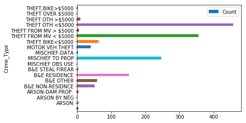

```python
crimetype_data.plot(x='Crime_Type', y='Count', kind='barh')
```

## Let's examine theft from vehicles

```python
mvcrime_df = crime_df.loc[crime_df['Crime_Type'] == 'THEFT FROM MV < $5000']
mvcrime_df
```

|  | Neighbourhood | Crime_Code | Crime_Type | Ward | City | FID |
| --- | --- | --- | --- | --- | --- | --- |
| 18 | Fredericton South | 2142 | THEFT FROM MV < $5000 | 7 | Fredericton | 19 |
| 19 | Fredericton South | 2142 | THEFT FROM MV < $5000 | 7 | Fredericton | 20 |
| 20 | Fredericton South | 2142 | THEFT FROM MV < $5000 | 7 | Fredericton | 21 |
| 21 | Fredericton South | 2142 | THEFT FROM MV < $5000 | 12 | Fredericton | 22 |
| 22 | Fredericton South | 2142 | THEFT FROM MV < $5000 | 12 | Fredericton | 23 |
| 23 | Fredericton South | 2142 | THEFT FROM MV < $5000 | 7 | Fredericton | 24 |
| 24 | Fredericton South | 2142 | THEFT FROM MV < $5000 | 7 | Fredericton | 25 |
| 25 | Fredericton South | 2142 | THEFT FROM MV < $5000 | 7 | Fredericton | 26 |
| 26 | Fredericton South | 2142 | THEFT FROM MV < $5000 | 11 | Fredericton | 27 |
| 27 | Fredericton South | 2142 | THEFT FROM MV < $5000 | 11 | Fredericton | 28 |
| 28 | Fredericton South | 2142 | THEFT FROM MV < $5000 | 12 | Fredericton | 29 |
| 29 | Fredericton South | 2142 | THEFT FROM MV < $5000 | 12 | Fredericton | 30 |
| 30 | Fredericton South | 2142 | THEFT FROM MV < $5000 | 7 | Fredericton | 31 |
| 51 | Barkers Point | 2142 | THEFT FROM MV < $5000 | 6 | Fredericton | 52 |
| 52 | Barkers Point | 2142 | THEFT FROM MV < $5000 | 6 | Fredericton | 53 |
| 53 | Barkers Point | 2142 | THEFT FROM MV < $5000 | 6 | Fredericton | 54 |
| 54 | Barkers Point | 2142 | THEFT FROM MV < $5000 | 6 | Fredericton | 55 |
| 55 | Barkers Point | 2142 | THEFT FROM MV < $5000 | 6 | Fredericton | 56 |
| 56 | Barkers Point | 2142 | THEFT FROM MV < $5000 | 6 | Fredericton | 57 |
| 57 | Barkers Point | 2142 | THEFT FROM MV < $5000 | 6 | Fredericton | 58 |
| 58 | Barkers Point | 2142 | THEFT FROM MV < $5000 | 6 | Fredericton | 59 |
| 100 | Sandyville | 2142 | THEFT FROM MV < $5000 | 5 | Fredericton | 101 |
| 107 | South Devon | 2142 | THEFT FROM MV < $5000 | 4 | Fredericton | 108 |
| 108 | South Devon | 2142 | THEFT FROM MV < $5000 | 4 | Fredericton | 109 |
| 109 | South Devon | 2142 | THEFT FROM MV < $5000 | 4 | Fredericton | 110 |
| 110 | South Devon | 2142 | THEFT FROM MV < $5000 | 4 | Fredericton | 111 |
| 111 | South Devon | 2142 | THEFT FROM MV < $5000 | 4 | Fredericton | 112 |
| 112 | South Devon | 2142 | THEFT FROM MV < $5000 | 4 | Fredericton | 113 |
| 113 | South Devon | 2142 | THEFT FROM MV < $5000 | 4 | Fredericton | 114 |
| 114 | South Devon | 2142 | THEFT FROM MV < $5000 | 4 | Fredericton | 115 |

[output cut: 326 more lines]

```python
mvcrime_data = mvcrime_df.groupby(['Neighbourhood']).size().to_frame(name='Count').reset_index()
mvcrime_data
```

|  | Neighbourhood | Count |
| --- | --- | --- |
| 0 | Barkers Point | 8 |
| 1 | Brookside Estates | 3 |
| 2 | College Hill | 10 |
| 3 | Colonial heights | 6 |
| 4 | Diamond Street | 1 |
| 5 | Douglas | 1 |
| 6 | Downtown | 21 |
| 7 | Dun's Crossing | 9 |
| 8 | Forest Hill | 8 |
| 9 | Fredericton South | 20 |
| 10 | Fulton Heights | 12 |
| 11 | Garden Creek | 1 |
| 12 | Garden Place | 3 |
| 13 | Gilridge Estates | 1 |
| 14 | Golf Club | 5 |
| 15 | Hanwell North | 3 |
| 16 | Heron Springs | 2 |
| 17 | Highpoint Ridge | 4 |
| 18 | Knob Hill | 1 |
| 19 | Lian / Valcore | 1 |
| 20 | Lincoln | 1 |
| 21 | Lincoln Heights | 11 |
| 22 | Main Street | 10 |
| 23 | Marysville | 10 |
| 24 | McKnight | 1 |
| 25 | McLeod Hill | 2 |
| 26 | Monteith / Talisman | 3 |
| 27 | Montogomery / Prospect East | 3 |
| 28 | Nashwaaksis | 9 |
| 29 | Nethervue Minihome Park | 1 |
| 30 | North Devon | 17 |
| 31 | Northbrook Heights | 5 |
| 32 | Plat | 40 |
| 33 | Poet's Hill | 2 |
| 34 | Prospect | 11 |
| 35 | Rail Side | 2 |
| 36 | Saint Mary's First Nation | 1 |
| 37 | Saint Thomas University | 1 |
| 38 | Sandyville | 3 |
| 39 | Shadowood Estates | 2 |
| 40 | Silverwood | 2 |
| 41 | Skyline Acrea | 13 |
| 42 | South Devon | 22 |
| 43 | Southwood Park | 7 |
| 44 | Sunshine Gardens | 7 |
| 45 | The Hill | 11 |
| 46 | University Of New Brunswick | 4 |
| 47 | Waterloo Row | 3 |
| 48 | Williams / Hawkins Area | 6 |
| 49 | Woodstock Road | 20 |
| 50 | Youngs Crossing | 6 |

```python
mvcrime_data.describe()
```

[output not shown]

```python
mvcrime_data.rename({'Platt': 'Plat'},inplace=True)
mvcrime_data.rename(index=str, columns={'Neighbourhood':'Neighbourh','Count':'MVCrime_Count'}, inplace=True)
mvcrime_data
```

|  | Neighbourh | MVCrime_Count |
| --- | --- | --- |
| 0 | Barkers Point | 8 |
| 1 | Brookside Estates | 3 |
| 2 | College Hill | 10 |
| 3 | Colonial heights | 6 |
| 4 | Diamond Street | 1 |
| 5 | Douglas | 1 |
| 6 | Downtown | 21 |
| 7 | Dun's Crossing | 9 |
| 8 | Forest Hill | 8 |
| 9 | Fredericton South | 20 |
| 10 | Fulton Heights | 12 |
| 11 | Garden Creek | 1 |
| 12 | Garden Place | 3 |
| 13 | Gilridge Estates | 1 |
| 14 | Golf Club | 5 |
| 15 | Hanwell North | 3 |
| 16 | Heron Springs | 2 |
| 17 | Highpoint Ridge | 4 |
| 18 | Knob Hill | 1 |
| 19 | Lian / Valcore | 1 |
| 20 | Lincoln | 1 |
| 21 | Lincoln Heights | 11 |
| 22 | Main Street | 10 |
| 23 | Marysville | 10 |
| 24 | McKnight | 1 |
| 25 | McLeod Hill | 2 |
| 26 | Monteith / Talisman | 3 |
| 27 | Montogomery / Prospect East | 3 |
| 28 | Nashwaaksis | 9 |
| 29 | Nethervue Minihome Park | 1 |
| 30 | North Devon | 17 |
| 31 | Northbrook Heights | 5 |
| 32 | Plat | 40 |
| 33 | Poet's Hill | 2 |
| 34 | Prospect | 11 |
| 35 | Rail Side | 2 |
| 36 | Saint Mary's First Nation | 1 |
| 37 | Saint Thomas University | 1 |
| 38 | Sandyville | 3 |
| 39 | Shadowood Estates | 2 |
| 40 | Silverwood | 2 |
| 41 | Skyline Acrea | 13 |
| 42 | South Devon | 22 |
| 43 | Southwood Park | 7 |
| 44 | Sunshine Gardens | 7 |
| 45 | The Hill | 11 |
| 46 | University Of New Brunswick | 4 |
| 47 | Waterloo Row | 3 |
| 48 | Williams / Hawkins Area | 6 |
| 49 | Woodstock Road | 20 |
| 50 | Youngs Crossing | 6 |

```python
## Motor Vehicle Crime <$5000 Count
fredericton_geo = r.json()
threshold_scale = np.linspace(mvcrime_data['MVCrime_Count'].min(), mvcrime_data['MVCrime_Count'].max(),6,dtype=int)
threshold_scale = threshold_scale.tolist()
threshold_scale[-1] = threshold_scale[-1]+1

fredericton_c_map.choropleth(geo_data=fredericton_geo,data=mvcrime_data,columns=['Neighbourh', 'MVCrime_Count'],key_on='feature.properties.Neighbourh',
    threshold_scale=threshold_scale, fill_color='YlOrRd',fill_opacity=0.7,line_opacity=0.1,legend_name='Fredericton Neighbourhoods')
fredericton_c_map
```

[interactive chart not shown]

## Is it possible the higher rate of crime in the downtown area is due to population density?

```python
opendemog = 'Fredericton_Census_Tract_Demographics.xlsx'

workbook = pd.ExcelFile(opendemog)
print(workbook.sheet_names)
```

```
['Fredericton_Census_Tract_Demogr']
```

```python
demog_df = workbook.parse('Fredericton_Census_Tract_Demogr')
demog_df.head()
```

|  | FID | OBJECTID | DBUID | DAUID | CDUID | CTUID | CTNAME | DBuid_1 | DBpop2011 | DBtdwell20 | DBurdwell2 | Shape_Leng | Shape_Area | CTIDLINK | Shape__Area | Shape__Length |
| --- | --- | --- | --- | --- | --- | --- | --- | --- | --- | --- | --- | --- | --- | --- | --- | --- |
| 0 | 1 | 501 | 1310024304 | 13100243 | 1310 | 3200002 | 2 | 1310024304 | 60 | 25 | 22 | 0.007462 | 0.000003 | 3200002 | 0.000003 | 0.007462 |
| 1 | 2 | 502 | 1310032004 | 13100320 | 1310 | 3200010 | 10 | 1310032004 | 15 | 3 | 3 | 0.009008 | 0.000003 | 3200010 | 0.000003 | 0.009008 |
| 2 | 3 | 503 | 1310017103 | 13100171 | 1310 | 3200014 | 14 | 1310017103 | 0 | 0 | 0 | 0.010602 | 0.000007 | 3200014 | 0.000007 | 0.010602 |
| 3 | 4 | 504 | 1310018301 | 13100183 | 1310 | 3200012 | 12 | 1310018301 | 108 | 60 | 50 | 0.039599 | 0.000068 | 3200012 | 0.000068 | 0.039599 |
| 4 | 5 | 505 | 1310022905 | 13100229 | 1310 | 3200007 | 7 | 1310022905 | 129 | 47 | 44 | 0.011833 | 0.000005 | 3200007 | 0.000005 | 0.011834 |

```python
# Population Density
world_geo = r'world_countries.json' # geojson file
fredericton_d_map = folium.Map(location=[45.94, -66.63], width=1200, height=750,zoom_start=12)
fredericton_d_map

threshold_scale = np.linspace(demog_df['DBpop2011'].min(),demog_df['DBpop2011'].max(),6,dtype=int)
threshold_scale = threshold_scale.tolist()
threshold_scale[-1] = threshold_scale[-1]+1

fredericton_d_map.choropleth(geo_data=demog_geo,data=demog_df,columns=['OBJECTID','DBpop2011'],key_on='feature.properties.OBJECTID',
    threshold_scale=threshold_scale,fill_color='PuBuGn',fill_opacity=0.7, line_opacity=0.1,legend_name='Fredericton Population Density')
fredericton_d_map
```

[interactive chart not shown]

## Let's look at specific locations in Fredericton

```python
pointbook = 'Fredericton Locations.xlsx'

workbook_2 = pd.ExcelFile(pointbook)
print(workbook_2.sheet_names)
```

```
['Sheet1']
```

```python
location_df = workbook_2.parse('Sheet1')
location_df
```

|  | Location | Neighbourh | Latitude | Longitude |
| --- | --- | --- | --- | --- |
| 0 | Knowledge Park | NaN | 45.931143 | -66.652700 |
| 1 | Fredericton Hill | NaN | 45.948512 | -66.656045 |
| 2 | Nashwaaksis | NaN | 45.983382 | -66.644856 |
| 3 | University of New Brunswick | NaN | 45.948121 | -66.641406 |
| 4 | Devon | NaN | 45.968802 | -66.622738 |
| 5 | New Maryland | NaN | 45.892795 | -66.683673 |
| 6 | Marysville | NaN | 45.978913 | -66.589491 |
| 7 | Skyline Acres | NaN | 45.931827 | -66.640339 |
| 8 | Hanwell | NaN | 45.902315 | -66.755113 |
| 9 | Downtown | NaN | 45.958327 | -66.647211 |

```python
location_df.drop(['Neighbourh'], axis=1,inplace=True)
location_df
```

|  | Location | Latitude | Longitude |
| --- | --- | --- | --- |
| 0 | Knowledge Park | 45.931143 | -66.652700 |
| 1 | Fredericton Hill | 45.948512 | -66.656045 |
| 2 | Nashwaaksis | 45.983382 | -66.644856 |
| 3 | University of New Brunswick | 45.948121 | -66.641406 |
| 4 | Devon | 45.968802 | -66.622738 |
| 5 | New Maryland | 45.892795 | -66.683673 |
| 6 | Marysville | 45.978913 | -66.589491 |
| 7 | Skyline Acres | 45.931827 | -66.640339 |
| 8 | Hanwell | 45.902315 | -66.755113 |
| 9 | Downtown | 45.958327 | -66.647211 |

### Add location markers to map

```python
for lat, lng, point in zip(location_df['Latitude'], location_df['Longitude'], location_df['Location']):
    label = '{}'.format(point)
    label = folium.Popup(label, parse_html=True)
    folium.CircleMarker([lat, lng],radium=1,popup=label,color='blue',fill=True,fill_color='#3186cc',fill_opacity=0.7,
        parse_html=False).add_to(fredericton_c_map)
fredericton_c_map
```

[interactive chart not shown]

## Explore Fredericton Neighbourhoods

#### Define Foursquare Credentials and Version

## Let's take a look at nearby venues

```python
def getNearbyVenues(names, latitudes, longitudes, radius=1000, LIMIT=100):

    venues_list=[]
    for name, lat, lng in zip(names, latitudes, longitudes):
        print(name)

        # create the API request URL
        url = 'https://api.foursquare.com/v2/venues/explore?&client_id={}&client_secret={}&v={}&ll={},{}&radius={}&limit={}'.format(
            CLIENT_ID,
            CLIENT_SECRET,
            VERSION,
            lat,
            lng,
            radius,
            LIMIT)

        # make the GET request
        results = requests.get(url).json()["response"]['groups'][0]['items']

        # return only relevant information for each nearby venue
        venues_list.append([(
            name,
            lat,
            lng,
            v['venue']['name'],
            v['venue']['id'],
            v['venue']['location']['lat'],
            v['venue']['location']['lng'],
            v['venue']['categories'][0]['name']) for v in results])

    nearby_venues = pd.DataFrame([item for venue_list in venues_list for item in venue_list])
    nearby_venues.columns = ['Location',
                  'Location Latitude',
                  'Location Longitude',
                  'Venue',
                  'Venue id',
                  'Venue Latitude',
                  'Venue Longitude',
                  'Venue Category'
                   ]

    return(nearby_venues)
```

```python
fredericton_data_venues = getNearbyVenues(names=location_df['Location'],
                                   latitudes=location_df['Latitude'],
                                   longitudes=location_df['Longitude']
                                  )
```

```
Knowledge Park
Fredericton Hill
Nashwaaksis
University of New Brunswick
Devon
New Maryland
Marysville
Skyline Acres
Hanwell
Downtown
```

```python
print(fredericton_data_venues.shape)
fredericton_data_venues
```

```
(166, 8)
```

|  | Location | Location Latitude | Location Longitude | Venue | Venue id | Venue Latitude | Venue Longitude | Venue Category |
| --- | --- | --- | --- | --- | --- | --- | --- | --- |
| 0 | Knowledge Park | 45.931143 | -66.652700 | Costco Wholesale | 4e18ab92183880768f43bff6 | 45.927034 | -66.663447 | Warehouse Store |
| 1 | Knowledge Park | 45.931143 | -66.652700 | PetSmart | 4bbca501a0a0c9b6078f1a0f | 45.929768 | -66.659939 | Pet Store |
| 2 | Knowledge Park | 45.931143 | -66.652700 | Montana's | 4e50406e62844166699b0780 | 45.931511 | -66.662507 | Restaurant |
| 3 | Knowledge Park | 45.931143 | -66.652700 | Boston Pizza | 4b64944af964a52041bf2ae3 | 45.938123 | -66.660037 | Sports Bar |
| 4 | Knowledge Park | 45.931143 | -66.652700 | Michaels | 4c489858417b20a13b82e1a9 | 45.929965 | -66.659548 | Arts & Crafts Store |
| 5 | Knowledge Park | 45.931143 | -66.652700 | Alcool NB Liquor | 4b77335df964a5202c872ee3 | 45.930680 | -66.664180 | Liquor Store |
| 6 | Knowledge Park | 45.931143 | -66.652700 | Best Buy | 5520124a498e0467bb6e81c8 | 45.937673 | -66.660380 | Electronics Store |
| 7 | Knowledge Park | 45.931143 | -66.652700 | Wal-Mart | 4bad313ff964a5208c373be3 | 45.934081 | -66.663539 | Big Box Store |
| 8 | Knowledge Park | 45.931143 | -66.652700 | Booster Juice | 4c42414e520fa59334f9caac | 45.935198 | -66.663602 | Smoothie Shop |
| 9 | Knowledge Park | 45.931143 | -66.652700 | Dairy Queen | 4b86f05bf964a52009a731e3 | 45.938004 | -66.659442 | Fast Food Restaurant |
| 10 | Knowledge Park | 45.931143 | -66.652700 | H&M | 509c3265498efdffc5739a0f | 45.935196 | -66.663290 | Clothing Store |
| 11 | Knowledge Park | 45.931143 | -66.652700 | Dairy Queen (Treat) | 4cc6123cbde8f04d9ce0b44b | 45.934520 | -66.663988 | Fast Food Restaurant |
| 12 | Knowledge Park | 45.931143 | -66.652700 | Winners | 4caa46a744a8224b96e42640 | 45.930427 | -66.659758 | Clothing Store |
| 13 | Knowledge Park | 45.931143 | -66.652700 | East Side Mario's | 4b55d89bf964a520a2f227e3 | 45.931376 | -66.663417 | Italian Restaurant |
| 14 | Knowledge Park | 45.931143 | -66.652700 | McDonald's | 4c6e9ef665eda09377e951d0 | 45.934575 | -66.663319 | Fast Food Restaurant |
| 15 | Knowledge Park | 45.931143 | -66.652700 | Home Sense | 54024f60498ee424eedb7bf9 | 45.930528 | -66.660103 | Department Store |
| 16 | Knowledge Park | 45.931143 | -66.652700 | The Shoe company | 4bd76dfa5cf276b0fb469b00 | 45.929636 | -66.660449 | Shoe Store |
| 17 | Knowledge Park | 45.931143 | -66.652700 | Avalon Spa Uptown | 4cd99e0f51fc8cfa4369f05d | 45.930774 | -66.660927 | Spa |
| 18 | Knowledge Park | 45.931143 | -66.652700 | Wicker Emporium | 4e6baff588772457c4fd1968 | 45.930897 | -66.661338 | Furniture / Home Store |
| 19 | Knowledge Park | 45.931143 | -66.652700 | Dollarama | 4ba3dd18f964a520d86738e3 | 45.930897 | -66.661714 | Discount Store |
| 20 | Knowledge Park | 45.931143 | -66.652700 | Bed Bath & Beyond | 5083f283e4b0bf87c15e9ea1 | 45.930097 | -66.662166 | Furniture / Home Store |
| 21 | Knowledge Park | 45.931143 | -66.652700 | GAP Factory Store | 50a8f005e4b0e4f42e033a2a | 45.930211 | -66.662416 | Clothing Store |
| 22 | Knowledge Park | 45.931143 | -66.652700 | carter's \| OshKosh B'gosh | 50a51363e4b0a3e2f7db76bf | 45.929978 | -66.662966 | Kids Store |
| 23 | Knowledge Park | 45.931143 | -66.652700 | Deluxe Fish & Chips | 4e5d0b99fa76a4cf148d9a15 | 45.931722 | -66.663131 | Seafood Restaurant |
| 24 | Knowledge Park | 45.931143 | -66.652700 | Hallmark | 4cd96cf651fc8cfa522eef5d | 45.930646 | -66.663745 | Gift Shop |
| 25 | Knowledge Park | 45.931143 | -66.652700 | NB Liquor | 5985f08b6cf01a7e38b85fba | 45.930228 | -66.664395 | Liquor Store |
| 26 | Knowledge Park | 45.931143 | -66.652700 | Corbett Center | 57854d05498e301b3b5a4448 | 45.929733 | -66.664601 | Shopping Plaza |
| 27 | Knowledge Park | 45.931143 | -66.652700 | Costco Food Court | 53693053498ef3e4ea63560f | 45.927383 | -66.663544 | Fast Food Restaurant |
| 28 | Knowledge Park | 45.931143 | -66.652700 | Sleep Country | 555b5660498eae864c440e77 | 45.929074 | -66.664605 | Mattress Store |
| 29 | Knowledge Park | 45.931143 | -66.652700 | Sport Chek Regent Mall | 4ca4ecae8a65bfb717422b22 | 45.935211 | -66.663525 | Sporting Goods Shop |

[output cut: 136 more lines]

```python
print('There are {} unique venue categories.'.format(len(fredericton_data_venues['Venue Category'].unique())))
```

```
There are 73 unique venue categories.
```

```python
print('There are {} unique venues.'.format(len(fredericton_data_venues['Venue id'].unique())))
```

```
There are 153 unique venues.
```

```python
univen = fredericton_data_venues.groupby('Location').nunique('Venue Category')
univen
```

| Location | Location | Location Latitude | Location Longitude | Venue | Venue id | Venue Latitude | Venue Longitude | Venue Category |
| --- | --- | --- | --- | --- | --- | --- | --- | --- |
| Devon | 1 | 1 | 1 | 12 | 12 | 12 | 12 | 11 |
| Downtown | 1 | 1 | 1 | 61 | 62 | 62 | 62 | 44 |
| Fredericton Hill | 1 | 1 | 1 | 17 | 17 | 17 | 17 | 13 |
| Hanwell | 1 | 1 | 1 | 2 | 2 | 2 | 2 | 2 |
| Knowledge Park | 1 | 1 | 1 | 31 | 31 | 31 | 31 | 23 |
| Marysville | 1 | 1 | 1 | 5 | 5 | 5 | 5 | 5 |
| Nashwaaksis | 1 | 1 | 1 | 17 | 19 | 19 | 19 | 15 |
| New Maryland | 1 | 1 | 1 | 4 | 4 | 4 | 4 | 4 |
| Skyline Acres | 1 | 1 | 1 | 4 | 4 | 4 | 4 | 3 |
| University of New Brunswick | 1 | 1 | 1 | 9 | 10 | 10 | 10 | 8 |

```python
fredericton_data_venues.groupby('Venue Category').nunique()
```

| Venue Category | Location | Location Latitude | Location Longitude | Venue | Venue id | Venue Latitude | Venue Longitude | Venue Category |
| --- | --- | --- | --- | --- | --- | --- | --- | --- |
| Art Gallery | 2 | 2 | 2 | 1 | 1 | 1 | 1 | 1 |
| Art Museum | 1 | 1 | 1 | 1 | 1 | 1 | 1 | 1 |
| Arts & Crafts Store | 2 | 2 | 2 | 2 | 2 | 2 | 2 | 1 |
| Auto Dealership | 1 | 1 | 1 | 1 | 1 | 1 | 1 | 1 |
| Bakery | 3 | 3 | 3 | 5 | 5 | 5 | 5 | 1 |
| Bank | 1 | 1 | 1 | 1 | 1 | 1 | 1 | 1 |
| Bar | 3 | 3 | 3 | 4 | 4 | 4 | 4 | 1 |
| Baseball Field | 3 | 3 | 3 | 3 | 3 | 3 | 3 | 1 |
| Baseball Stadium | 1 | 1 | 1 | 1 | 1 | 1 | 1 | 1 |
| Basketball Court | 1 | 1 | 1 | 1 | 1 | 1 | 1 | 1 |
| Beer Store | 1 | 1 | 1 | 1 | 1 | 1 | 1 | 1 |
| Big Box Store | 1 | 1 | 1 | 1 | 1 | 1 | 1 | 1 |
| Bookstore | 1 | 1 | 1 | 1 | 1 | 1 | 1 | 1 |
| Breakfast Spot | 1 | 1 | 1 | 1 | 1 | 1 | 1 | 1 |
| Brewery | 1 | 1 | 1 | 1 | 1 | 1 | 1 | 1 |
| Burger Joint | 2 | 2 | 2 | 1 | 1 | 1 | 1 | 1 |
| Café | 1 | 1 | 1 | 3 | 3 | 3 | 3 | 1 |
| Chinese Restaurant | 2 | 2 | 2 | 3 | 3 | 3 | 3 | 1 |
| Clothing Store | 1 | 1 | 1 | 3 | 3 | 3 | 3 | 1 |
| Coffee Shop | 7 | 7 | 7 | 6 | 13 | 13 | 13 | 1 |
| Dance Studio | 1 | 1 | 1 | 1 | 1 | 1 | 1 | 1 |
| Department Store | 2 | 2 | 2 | 2 | 2 | 2 | 2 | 1 |
| Discount Store | 1 | 1 | 1 | 1 | 1 | 1 | 1 | 1 |
| Electronics Store | 2 | 2 | 2 | 2 | 2 | 2 | 2 | 1 |
| Farmers Market | 2 | 2 | 2 | 3 | 3 | 3 | 3 | 1 |
| Fast Food Restaurant | 5 | 5 | 5 | 9 | 10 | 10 | 10 | 1 |
| Furniture / Home Store | 1 | 1 | 1 | 2 | 2 | 2 | 2 | 1 |
| Gas Station | 2 | 2 | 2 | 1 | 2 | 2 | 2 | 1 |
| Gastropub | 1 | 1 | 1 | 1 | 1 | 1 | 1 | 1 |
| Gift Shop | 1 | 1 | 1 | 1 | 1 | 1 | 1 | 1 |
| Greek Restaurant | 1 | 1 | 1 | 1 | 1 | 1 | 1 | 1 |
| Grocery Store | 4 | 4 | 4 | 4 | 4 | 4 | 4 | 1 |
| Gym | 4 | 4 | 4 | 2 | 2 | 2 | 2 | 1 |
| Gym / Fitness Center | 1 | 1 | 1 | 1 | 1 | 1 | 1 | 1 |
| Hardware Store | 1 | 1 | 1 | 1 | 1 | 1 | 1 | 1 |
| Hobby Shop | 1 | 1 | 1 | 1 | 1 | 1 | 1 | 1 |
| Hockey Arena | 3 | 3 | 3 | 3 | 3 | 3 | 3 | 1 |
| Ice Cream Shop | 2 | 2 | 2 | 1 | 1 | 1 | 1 | 1 |
| Italian Restaurant | 2 | 2 | 2 | 2 | 2 | 2 | 2 | 1 |
| Kids Store | 1 | 1 | 1 | 1 | 1 | 1 | 1 | 1 |
| Korean Restaurant | 1 | 1 | 1 | 1 | 1 | 1 | 1 | 1 |
| Liquor Store | 2 | 2 | 2 | 2 | 3 | 3 | 3 | 1 |
| Mattress Store | 1 | 1 | 1 | 1 | 1 | 1 | 1 | 1 |
| Mexican Restaurant | 1 | 1 | 1 | 1 | 1 | 1 | 1 | 1 |
| Nightclub | 1 | 1 | 1 | 1 | 1 | 1 | 1 | 1 |
| Park | 4 | 4 | 4 | 4 | 4 | 4 | 4 | 1 |
| Performing Arts Venue | 1 | 1 | 1 | 1 | 1 | 1 | 1 | 1 |
| Pet Store | 1 | 1 | 1 | 1 | 1 | 1 | 1 | 1 |
| Pharmacy | 5 | 5 | 5 | 3 | 5 | 5 | 5 | 1 |
| Pizza Place | 4 | 4 | 4 | 5 | 5 | 5 | 5 | 1 |
| Pub | 2 | 2 | 2 | 6 | 6 | 6 | 6 | 1 |
| Racetrack | 1 | 1 | 1 | 1 | 1 | 1 | 1 | 1 |
| Rental Car Location | 1 | 1 | 1 | 1 | 1 | 1 | 1 | 1 |
| Rental Service | 1 | 1 | 1 | 1 | 1 | 1 | 1 | 1 |
| Restaurant | 2 | 2 | 2 | 5 | 5 | 5 | 5 | 1 |
| Sandwich Place | 3 | 3 | 3 | 1 | 4 | 4 | 4 | 1 |
| Seafood Restaurant | 3 | 3 | 3 | 3 | 3 | 3 | 3 | 1 |
| Shoe Store | 1 | 1 | 1 | 1 | 1 | 1 | 1 | 1 |
| Shopping Mall | 1 | 1 | 1 | 1 | 1 | 1 | 1 | 1 |
| Shopping Plaza | 1 | 1 | 1 | 1 | 1 | 1 | 1 | 1 |
| Skating Rink | 1 | 1 | 1 | 1 | 1 | 1 | 1 | 1 |
| Smoke Shop | 2 | 2 | 2 | 2 | 2 | 2 | 2 | 1 |
| Smoothie Shop | 1 | 1 | 1 | 1 | 1 | 1 | 1 | 1 |
| Spa | 2 | 2 | 2 | 2 | 2 | 2 | 2 | 1 |
| Sporting Goods Shop | 2 | 2 | 2 | 2 | 2 | 2 | 2 | 1 |
| Sports Bar | 1 | 1 | 1 | 1 | 1 | 1 | 1 | 1 |
| Steakhouse | 1 | 1 | 1 | 1 | 1 | 1 | 1 | 1 |
| Supermarket | 1 | 1 | 1 | 1 | 1 | 1 | 1 | 1 |
| Sushi Restaurant | 1 | 1 | 1 | 1 | 1 | 1 | 1 | 1 |
| Thai Restaurant | 1 | 1 | 1 | 1 | 1 | 1 | 1 | 1 |
| Toy / Game Store | 1 | 1 | 1 | 1 | 1 | 1 | 1 | 1 |
| Video Store | 2 | 2 | 2 | 1 | 1 | 1 | 1 | 1 |
| Warehouse Store | 1 | 1 | 1 | 1 | 1 | 1 | 1 | 1 |

## Analyze each Location

```python
# one hot encoding
freddy_onehot = pd.get_dummies(fredericton_data_venues[['Venue Category']], prefix="", prefix_sep="")

# add neighbourhood column back to dataframe
freddy_onehot['Location'] = fredericton_data_venues['Location']

# move neighbourhood column to the first column
fixed_columns = [freddy_onehot.columns[-1]] + list(freddy_onehot.columns[:-1])
freddy_onehot = freddy_onehot[fixed_columns]

freddy_onehot.head()
```

|  | Location | Art Gallery | Art Museum | Arts & Crafts Store | Auto Dealership | Bakery | Bank | Bar | Baseball Field | Baseball Stadium | Basketball Court | Beer Store | Big Box Store | Bookstore | Breakfast Spot | Brewery | Burger Joint | Café | Chinese Restaurant | Clothing Store | Coffee Shop | Dance Studio | Department Store | Discount Store | Electronics Store | Farmers Market | Fast Food Restaurant | Furniture / Home Store | Gas Station | … |
| --- | --- | --- | --- | --- | --- | --- | --- | --- | --- | --- | --- | --- | --- | --- | --- | --- | --- | --- | --- | --- | --- | --- | --- | --- | --- | --- | --- | --- | --- | --- |
| 0 | Knowledge Park | 0 | 0 | 0 | 0 | 0 | 0 | 0 | 0 | 0 | 0 | 0 | 0 | 0 | 0 | 0 | 0 | 0 | 0 | 0 | 0 | 0 | 0 | 0 | 0 | 0 | 0 | 0 | 0 | … |
| 1 | Knowledge Park | 0 | 0 | 0 | 0 | 0 | 0 | 0 | 0 | 0 | 0 | 0 | 0 | 0 | 0 | 0 | 0 | 0 | 0 | 0 | 0 | 0 | 0 | 0 | 0 | 0 | 0 | 0 | 0 | … |
| 2 | Knowledge Park | 0 | 0 | 0 | 0 | 0 | 0 | 0 | 0 | 0 | 0 | 0 | 0 | 0 | 0 | 0 | 0 | 0 | 0 | 0 | 0 | 0 | 0 | 0 | 0 | 0 | 0 | 0 | 0 | … |
| 3 | Knowledge Park | 0 | 0 | 0 | 0 | 0 | 0 | 0 | 0 | 0 | 0 | 0 | 0 | 0 | 0 | 0 | 0 | 0 | 0 | 0 | 0 | 0 | 0 | 0 | 0 | 0 | 0 | 0 | 0 | … |
| 4 | Knowledge Park | 0 | 0 | 1 | 0 | 0 | 0 | 0 | 0 | 0 | 0 | 0 | 0 | 0 | 0 | 0 | 0 | 0 | 0 | 0 | 0 | 0 | 0 | 0 | 0 | 0 | 0 | 0 | 0 | … |

```python
freddy_onehot.shape
```

```
(166, 74)
```

### Group rows by location and by the mean of the frequency of occurrence of each category

```python
freddy_grouped = freddy_onehot.groupby('Location').mean().reset_index()
freddy_grouped
```

|  | Location | Art Gallery | Art Museum | Arts & Crafts Store | Auto Dealership | Bakery | Bank | Bar | Baseball Field | Baseball Stadium | Basketball Court | Beer Store | Big Box Store | Bookstore | Breakfast Spot | Brewery | Burger Joint | Café | Chinese Restaurant | Clothing Store | Coffee Shop | Dance Studio | Department Store | Discount Store | Electronics Store | Farmers Market | Fast Food Restaurant | Furniture / Home Store | Gas Station | … |
| --- | --- | --- | --- | --- | --- | --- | --- | --- | --- | --- | --- | --- | --- | --- | --- | --- | --- | --- | --- | --- | --- | --- | --- | --- | --- | --- | --- | --- | --- | --- |
| 0 | Devon | 0.000000 | 0.000000 | 0.000000 | 0.000000 | 0.000000 | 0.000000 | 0.000000 | 0.083333 | 0.0 | 0.0 | 0.000000 | 0.000000 | 0.000000 | 0.000000 | 0.000000 | 0.000000 | 0.000000 | 0.000000 | 0.000000 | 0.083333 | 0.00 | 0.083333 | 0.000000 | 0.000000 | 0.000000 | 0.166667 | 0.000000 | 0.00 | … |
| 1 | Downtown | 0.016129 | 0.016129 | 0.000000 | 0.000000 | 0.016129 | 0.016129 | 0.048387 | 0.000000 | 0.0 | 0.0 | 0.000000 | 0.000000 | 0.016129 | 0.016129 | 0.016129 | 0.016129 | 0.048387 | 0.016129 | 0.000000 | 0.096774 | 0.00 | 0.000000 | 0.000000 | 0.000000 | 0.016129 | 0.016129 | 0.000000 | 0.00 | … |
| 2 | Fredericton Hill | 0.000000 | 0.000000 | 0.000000 | 0.000000 | 0.176471 | 0.000000 | 0.058824 | 0.000000 | 0.0 | 0.0 | 0.000000 | 0.000000 | 0.000000 | 0.000000 | 0.000000 | 0.000000 | 0.000000 | 0.000000 | 0.000000 | 0.058824 | 0.00 | 0.000000 | 0.000000 | 0.000000 | 0.000000 | 0.000000 | 0.000000 | 0.00 | … |
| 3 | Hanwell | 0.000000 | 0.000000 | 0.000000 | 0.000000 | 0.000000 | 0.000000 | 0.000000 | 0.000000 | 0.0 | 0.0 | 0.000000 | 0.000000 | 0.000000 | 0.000000 | 0.000000 | 0.000000 | 0.000000 | 0.000000 | 0.000000 | 0.500000 | 0.00 | 0.000000 | 0.000000 | 0.000000 | 0.000000 | 0.000000 | 0.000000 | 0.00 | … |
| 4 | Knowledge Park | 0.000000 | 0.000000 | 0.032258 | 0.000000 | 0.000000 | 0.000000 | 0.000000 | 0.000000 | 0.0 | 0.0 | 0.000000 | 0.032258 | 0.000000 | 0.000000 | 0.000000 | 0.000000 | 0.000000 | 0.000000 | 0.096774 | 0.000000 | 0.00 | 0.032258 | 0.032258 | 0.032258 | 0.000000 | 0.129032 | 0.064516 | 0.00 | … |
| 5 | Marysville | 0.000000 | 0.000000 | 0.000000 | 0.000000 | 0.000000 | 0.000000 | 0.000000 | 0.000000 | 0.2 | 0.0 | 0.000000 | 0.000000 | 0.000000 | 0.000000 | 0.000000 | 0.000000 | 0.000000 | 0.000000 | 0.000000 | 0.200000 | 0.00 | 0.000000 | 0.000000 | 0.000000 | 0.000000 | 0.000000 | 0.000000 | 0.20 | … |
| 6 | Nashwaaksis | 0.000000 | 0.000000 | 0.052632 | 0.052632 | 0.052632 | 0.000000 | 0.000000 | 0.000000 | 0.0 | 0.0 | 0.052632 | 0.000000 | 0.000000 | 0.000000 | 0.000000 | 0.000000 | 0.000000 | 0.000000 | 0.000000 | 0.105263 | 0.00 | 0.000000 | 0.000000 | 0.052632 | 0.105263 | 0.105263 | 0.000000 | 0.00 | … |
| 7 | New Maryland | 0.000000 | 0.000000 | 0.000000 | 0.000000 | 0.000000 | 0.000000 | 0.000000 | 0.250000 | 0.0 | 0.0 | 0.000000 | 0.000000 | 0.000000 | 0.000000 | 0.000000 | 0.000000 | 0.000000 | 0.000000 | 0.000000 | 0.000000 | 0.25 | 0.000000 | 0.000000 | 0.000000 | 0.000000 | 0.250000 | 0.000000 | 0.25 | … |
| 8 | Skyline Acres | 0.000000 | 0.000000 | 0.000000 | 0.000000 | 0.000000 | 0.000000 | 0.000000 | 0.250000 | 0.0 | 0.0 | 0.000000 | 0.000000 | 0.000000 | 0.000000 | 0.000000 | 0.000000 | 0.000000 | 0.500000 | 0.000000 | 0.000000 | 0.00 | 0.000000 | 0.000000 | 0.000000 | 0.000000 | 0.000000 | 0.000000 | 0.00 | … |
| 9 | University of New Brunswick | 0.100000 | 0.000000 | 0.000000 | 0.000000 | 0.000000 | 0.000000 | 0.200000 | 0.000000 | 0.0 | 0.1 | 0.000000 | 0.000000 | 0.000000 | 0.000000 | 0.000000 | 0.100000 | 0.000000 | 0.000000 | 0.000000 | 0.200000 | 0.00 | 0.000000 | 0.000000 | 0.000000 | 0.000000 | 0.000000 | 0.000000 | 0.00 | … |

```python
freddy_grouped.shape
```

```
(10, 74)
```

### Print each Location with the top 5 most common venues

```python
num_top_venues = 5

for hood in freddy_grouped['Location']:
    print("----"+hood+"----")
    temp = freddy_grouped[freddy_grouped['Location'] == hood].T.reset_index()
    temp.columns = ['venue','freq']
    temp = temp.iloc[1:]
    temp['freq'] = temp['freq'].astype(float)
    temp = temp.round({'freq': 2})
    print(temp.sort_values('freq', ascending=False).reset_index(drop=True).head(num_top_venues))
    print('\n')
```

```
----Devon----
                  venue  freq
0  Fast Food Restaurant  0.17
1           Coffee Shop  0.08
2         Grocery Store  0.08
3    Seafood Restaurant  0.08
4          Skating Rink  0.08


----Downtown----
         venue  freq
0  Coffee Shop  0.10
1          Pub  0.08
2         Café  0.05
3   Restaurant  0.05
4          Bar  0.05


----Fredericton Hill----
            venue  freq
0          Bakery  0.18
1     Pizza Place  0.18
2    Hockey Arena  0.06
3      Smoke Shop  0.06
4  Ice Cream Shop  0.06


----Hanwell----
                 venue  freq
0          Coffee Shop   0.5
1       Rental Service   0.5
2          Art Gallery   0.0
3  Rental Car Location   0.0
4            Racetrack   0.0


----Knowledge Park----
                    venue  freq
0    Fast Food Restaurant  0.13
1          Clothing Store  0.10
```

[output cut: 33 more lines]

```
                venue  freq
0  Chinese Restaurant  0.50
1        Hockey Arena  0.25
2      Baseball Field  0.25
3           Pet Store  0.00
4      Rental Service  0.00


----University of New Brunswick----
              venue  freq
0       Coffee Shop   0.2
1               Bar   0.2
2  Basketball Court   0.1
3               Gym   0.1
4     Grocery Store   0.1
```

### Now into a pandas dataframe

```python
def return_most_common_venues(row, num_top_venues):
    row_categories = row.iloc[1:]
    row_categories_sorted = row_categories.sort_values(ascending=False)

    return row_categories_sorted.index.values[0:num_top_venues]
```

```python
num_top_venues = 10

indicators = ['st', 'nd', 'rd']

# create columns according to number of top venues
columns = ['Location']
for ind in np.arange(num_top_venues):
    try:
        columns.append('{}{} Most Common Venue'.format(ind+1, indicators[ind]))
    except:
        columns.append('{}th Most Common Venue'.format(ind+1))

# create a new dataframe
location_venues_sorted = pd.DataFrame(columns=columns)
location_venues_sorted['Location'] = freddy_grouped['Location']

for ind in np.arange(freddy_grouped.shape[0]):
    location_venues_sorted.iloc[ind, 1:] = return_most_common_venues(freddy_grouped.iloc[ind, :], num_top_venues)

location_venues_sorted
```

|  | Location | 1st Most Common Venue | 2nd Most Common Venue | 3rd Most Common Venue | 4th Most Common Venue | 5th Most Common Venue | 6th Most Common Venue | 7th Most Common Venue | 8th Most Common Venue | 9th Most Common Venue | 10th Most Common Venue |
| --- | --- | --- | --- | --- | --- | --- | --- | --- | --- | --- | --- |
| 0 | Devon | Fast Food Restaurant | Grocery Store | Smoke Shop | Pharmacy | Coffee Shop | Seafood Restaurant | Park | Department Store | Skating Rink | Pizza Place |
| 1 | Downtown | Coffee Shop | Pub | Bar | Café | Restaurant | Park | Pizza Place | Grocery Store | Hockey Arena | Greek Restaurant |
| 2 | Fredericton Hill | Bakery | Pizza Place | Hockey Arena | Smoke Shop | Hardware Store | Video Store | Ice Cream Shop | Park | Pharmacy | Coffee Shop |
| 3 | Hanwell | Rental Service | Coffee Shop | Warehouse Store | Dance Studio | Department Store | Discount Store | Electronics Store | Farmers Market | Fast Food Restaurant | Furniture / Home Store |
| 4 | Knowledge Park | Fast Food Restaurant | Clothing Store | Furniture / Home Store | Liquor Store | Restaurant | Warehouse Store | Shoe Store | Pet Store | Mattress Store | Gift Shop |
| 5 | Marysville | Baseball Stadium | Gas Station | Pharmacy | Park | Coffee Shop | Gift Shop | Gastropub | Greek Restaurant | Furniture / Home Store | Clothing Store |
| 6 | Nashwaaksis | Coffee Shop | Sandwich Place | Farmers Market | Fast Food Restaurant | Gym | Spa | Electronics Store | Beer Store | Pizza Place | Pharmacy |
| 7 | New Maryland | Gas Station | Dance Studio | Fast Food Restaurant | Baseball Field | Furniture / Home Store | Department Store | Discount Store | Electronics Store | Farmers Market | Warehouse Store |
| 8 | Skyline Acres | Chinese Restaurant | Baseball Field | Hockey Arena | Arts & Crafts Store | Coffee Shop | Gym / Fitness Center | Gym | Grocery Store | Greek Restaurant | Gift Shop |
| 9 | University of New Brunswick | Bar | Coffee Shop | Art Gallery | Pub | Burger Joint | Basketball Court | Grocery Store | Gym | Gift Shop | Greek Restaurant |

## Cluster Fredericton Locations

### Run k-means to cluster Locations into 5 clusters

```python
# set number of clusters
kclusters = 5

freddy_grouped_clustering = freddy_grouped.drop('Location', 1)

# run k-means clustering
kmeans = KMeans(n_clusters=kclusters, random_state=0).fit(freddy_grouped_clustering)

# check cluster labels generated for each row in the dataframe
kmeans.labels_[0:10]
```

```
array([1, 1, 1, 0, 1, 4, 1, 3, 2, 1], dtype=int32)
```

### Now creating a new dataframe including the cluster as well as the top 10 venues for each Location

```python
freddy_merged = location_df

# add clustering labels
freddy_merged['Cluster Labels'] = kmeans.labels_

# merge fredericton_grouped with location df to add latitude/longitude for each location
freddy_merged = freddy_merged.join(location_venues_sorted.set_index('Location'), on='Location')

freddy_merged# check the last columns!
```

|  | Location | Latitude | Longitude | Cluster Labels | 1st Most Common Venue | 2nd Most Common Venue | 3rd Most Common Venue | 4th Most Common Venue | 5th Most Common Venue | 6th Most Common Venue | 7th Most Common Venue | 8th Most Common Venue | 9th Most Common Venue | 10th Most Common Venue |
| --- | --- | --- | --- | --- | --- | --- | --- | --- | --- | --- | --- | --- | --- | --- |
| 0 | Knowledge Park | 45.931143 | -66.652700 | 1 | Fast Food Restaurant | Clothing Store | Furniture / Home Store | Liquor Store | Restaurant | Warehouse Store | Shoe Store | Pet Store | Mattress Store | Gift Shop |
| 1 | Fredericton Hill | 45.948512 | -66.656045 | 1 | Bakery | Pizza Place | Hockey Arena | Smoke Shop | Hardware Store | Video Store | Ice Cream Shop | Park | Pharmacy | Coffee Shop |
| 2 | Nashwaaksis | 45.983382 | -66.644856 | 1 | Coffee Shop | Sandwich Place | Farmers Market | Fast Food Restaurant | Gym | Spa | Electronics Store | Beer Store | Pizza Place | Pharmacy |
| 3 | University of New Brunswick | 45.948121 | -66.641406 | 0 | Bar | Coffee Shop | Art Gallery | Pub | Burger Joint | Basketball Court | Grocery Store | Gym | Gift Shop | Greek Restaurant |
| 4 | Devon | 45.968802 | -66.622738 | 1 | Fast Food Restaurant | Grocery Store | Smoke Shop | Pharmacy | Coffee Shop | Seafood Restaurant | Park | Department Store | Skating Rink | Pizza Place |
| 5 | New Maryland | 45.892795 | -66.683673 | 4 | Gas Station | Dance Studio | Fast Food Restaurant | Baseball Field | Furniture / Home Store | Department Store | Discount Store | Electronics Store | Farmers Market | Warehouse Store |
| 6 | Marysville | 45.978913 | -66.589491 | 1 | Baseball Stadium | Gas Station | Pharmacy | Park | Coffee Shop | Gift Shop | Gastropub | Greek Restaurant | Furniture / Home Store | Clothing Store |
| 7 | Skyline Acres | 45.931827 | -66.640339 | 3 | Chinese Restaurant | Baseball Field | Hockey Arena | Arts & Crafts Store | Coffee Shop | Gym / Fitness Center | Gym | Grocery Store | Greek Restaurant | Gift Shop |
| 8 | Hanwell | 45.902315 | -66.755113 | 2 | Rental Service | Coffee Shop | Warehouse Store | Dance Studio | Department Store | Discount Store | Electronics Store | Farmers Market | Fast Food Restaurant | Furniture / Home Store |
| 9 | Downtown | 45.958327 | -66.647211 | 1 | Coffee Shop | Pub | Bar | Café | Restaurant | Park | Pizza Place | Grocery Store | Hockey Arena | Greek Restaurant |

```python
# create map
map_clusters = folium.Map(location=[latitude, longitude], zoom_start=11)

# set color scheme for the clusters
x = np.arange(kclusters)
ys = [i+x+(i*x)**2 for i in range(kclusters)]
colors_array = cm.rainbow(np.linspace(0, 1, len(ys)))
rainbow = [colors.rgb2hex(i) for i in colors_array]

# add markers to the map
markers_colors = []
for lat, lon, poi, cluster in zip(freddy_merged['Latitude'], freddy_merged['Longitude'], freddy_merged['Location'], freddy_merged['Cluster Labels']):
    label = folium.Popup(str(poi) + ' Cluster ' + str(cluster), parse_html=True)
    folium.CircleMarker([lat, lon], radius=5,popup=label,color=rainbow[cluster-1],fill=True,fill_color=rainbow[cluster-1],
        fill_opacity=0.7).add_to(map_clusters)
map_clusters
```

[interactive chart not shown]